# Regression Analysis

Do Won Kim

2025-02-12

```r
# Load packages
if (!require("pacman")) install.packages("pacman")
pacman::p_load(
  conflicted,    # Avoid conflict of functions with same names
  tidyverse,     # Tidyverse umbrella package
  readr,         # read_csv()
  arrow,         # Load parquet files
  car,           # vif()
  betareg,       # betareg()
  sjPlot,        # tab_xtab()
  kableExtra,    # kbl()
  broom,         # tidy()
  DT             # datatable()
)

conflict_prefer("select", "dplyr")
conflict_prefer("filter", "dplyr")
```

# 1 Data Prep

```r
# Set the base directory (When you replicate this, change this to your working directory)
base_dir <- "/Users/dowonkim/Desktop/domain_audience_diversity/data"

# Define subdirectories for different data categories
sub_dirs <- c("age", "gender", "meta_stats", "party", "race")

# Generate full paths for each subdirectory
dirs <- file.path(base_dir, sub_dirs)

# Function to read all Parquet files in a directory and store them in a named list
read_all_parquet <- function(dir) {
  files <- list.files(dir, pattern = "\\.parquet$", full.names = TRUE)
  dfs <- lapply(files, read_parquet)
  names(dfs) <- tools::file_path_sans_ext(basename(files))  # Assign file names as list names
  return(dfs)
}

# Read all Parquet files from the defined directories
df_list <- lapply(dirs, read_all_parquet)
df_list <- do.call(c, df_list)  # Flatten the nested list

# Remove raw_counts
df_list <- df_list[!names(df_list) %in% c("gender_raw_count_shares", "gender_raw_count_users",
                                          "race_raw_count_shares", "race_raw_count_users")]

# Merge all data frames based on the 'domain' key
merged_df <- Reduce(function(x, y) merge(x, y, by = "domain", all = TRUE), df_list)

# Now bring the NewsGuard scores
newsguard_path <- file.path(base_dir, "reliability", "newsguard_2022_01.csv")
newsguard_scores <- read_csv(newsguard_path)

# Merge NewsGuard data with the main dataset
final_df <- merge(merged_df, newsguard_scores, by = "domain", all.x = TRUE)

# Check the final dataset
final_df |> datatable(filter = 'top')
```

|  | domain | age_deviation_score_shares | age_deviation_score_users | average_yob_shares | variance_yob_shares | average_yob_users | variance_yob_users | gender_leaning_score_shares | gender_leaning_score_users | average_gender_score_shares | variance_gender_score_shares | average_gender_score_users | variance_gender_score_users | users | shares | political_leaning_score_shares | political_leaning_score_users | average_party_score_shares | variance_party_score_shares | average_party_score_users | variance_party_score_users | race_deviation_score_shares | race_deviation_score_users | newsguard_rating | newsguard_score |
| --- | --- | --- | --- | --- | --- | --- | --- | --- | --- | --- | --- | --- | --- | --- | --- | --- | --- | --- | --- | --- | --- | --- | --- | --- | --- |
| 1 | 100percentfedup.com | 0.9237364907907635 | 1.019998148770005 | 1957.097782158699 | 114.7345580993888 | 1961.797429015398 | 148.3517255168213 | 0.1780879160739126 | -0.07664015922337652 | 0.3585916384621003 | 0.2300064755315804 | 0.4818748229963183 | 0.2497068371822023 | 7471 | 86796 | 0.7827873482912364 | 0.6980470423221085 | 0.7321850973118798 | 0.1012016829164928 | 0.7197585823488533 | 0.1079946624489215 | 0.08106346389759359 | 0.05912522328971723 | N | 12.5 |
| 2 | 1011now.com | 0.2308784502101749 | 0.0767960031841914 | 1979.578157267673 | 101.2605126101069 | 1976.419193857965 | 197.9931798414353 | 0.1571060671887624 | -0.1517689022949955 | 0.3685822519545418 | 0.232748134919546 | 0.5199362041467305 | 0.2497021100090406 | 2743 | 13896 | 0.2144341427306147 | 0.2855574234184101 | 0.4405882120253165 | 0.1727321618516965 | 0.5262481060606061 | 0.1634971779047102 | 0.1864901554418301 | 0.1108378797048588 | T | 100 |
| 3 | 10news.com | 0.09217136395396763 | 0.2145465773531605 | 1973.413818123186 | 154.4138244506508 | 1971.980334839224 | 222.2587494426841 | 0.2042343342172183 | -0.01241897984063089 | 0.3462051709758132 | 0.2263565899561605 | 0.4498505028540364 | 0.24751866733086 | 7960 | 25948 | 0.03745637142673899 | -0.0781026961922883 | 0.4133656387665198 | 0.1234767791066065 | 0.388154628422425 | 0.1422078861143164 | 0.05585376279057603 | 0.009510886620190577 | T | 100 |
| 4 | 10tv.com | 0.3141475604801208 | 0.2189142367865632 | 1982.827231222386 | 210.0227138760268 | 1984.535602138674 | 238.5474911863204 | -0.0251838750588241 | -0.01856032231287924 | 0.4573317495545622 | 0.2481832993589359 | 0.4528928587459042 | 0.2477920394673594 | 25032 | 71375 | -0.04788253875741601 | -0.05902634011927534 | 0.3652807504809848 | 0.1110424897175466 | 0.404192824179936 | 0.1201881772693105 | 0.007931694370251619 | 0.01645850775749735 | T | 95 |
| 5 | 11alive.com | 0.01363940128955324 | 0.136638261639746 | 1972.421467815379 | 207.3174226530545 | 1973.880960320107 | 225.6825739743557 | 0.1659505282700654 | 0.06986121002128462 | 0.3643653812899879 | 0.2316082564380756 | 0.4094923481426549 | 0.2418246681082469 | 16015 | 51692 | -0.01468869781323937 | -0.0749086544739177 | 0.3479734182269011 | 0.1427558031725225 | 0.3811694160775072 | 0.1471859110671808 | 0.1269555123453269 | 0.06366190693391213 | T | 100 |
| 6 | 12news.com | 0.0738297435825762 | 0.1338193495534329 | 1973.703366880886 | 240.3655622287285 | 1977.071413207141 | 284.5714296687289 | 0.01690808813780576 | -0.01526836019668934 | 0.4365226381768836 | 0.2459812212370157 | 0.4512615316216517 | 0.2476520877741334 | 9886 | 26043 | 0.1041609872290628 | 0.03284886307168995 | 0.3962140353672136 | 0.1418599754560061 | 0.4226592249368155 | 0.1414560612166295 | 0.06597854479102992 | 0.01810101074588282 | T | 100 |
| 7 | 12newsnow.com | 0.262778970073026 | 0.09448227610888295 | 1984.689564957393 | 122.1876177968173 | 1975.111420612813 | 265.3844570108367 | 0.529374961587186 | -0.001107046384699086 | 0.1978128979102689 | 0.1586948416943059 | 0.4442577030812325 | 0.2470311891572775 | 1898 | 13553 | -0.2153176622021255 | 0.2579385917324892 | 0.3994163621448281 | 0.08160989860159194 | 0.5065481033534909 | 0.1507522346209879 | 0.09586057695382555 | 0.01025312116461641 | T | 100 |
| 8 | 12thmanrising.com | 0.2121174521462173 | 0.08752242760063325 | 1975.51497005988 | 111.4637391882905 | 1977.739130434783 | 185.639479530308 | 0.04083664547344796 | -0.5894722532893434 | 0.4247787610619469 | 0.2450646698434311 | 0.7553956834532374 | 0.1861119799812325 | 151 | 355 | -0.2895841181481565 | -0.06142843271142685 | 0.2666352941176471 | 0.1049212235294117 | 0.4035 | 0.1116767410071942 | 0.0339065743347165 | 0.0364216605432353 | T | 87.5 |
| 9 | 12up.com | 0.2417136482032775 | 0.1373174042838815 | 1981.867837302358 | 226.0333481935916 | 1983.341906721536 | 208.9713174993246 | -0.6807851681542145 | -0.6407168598513124 | 0.8084057854882006 | 0.1548920773381105 | 0.7845977214519121 | 0.1690190640011673 | 12360 | 27100 | 0.3625401981360789 | 0.2960248984970378 | 0.5013332188644689 | 0.134146762200926 | 0.524764794635373 | 0.1301987256277758 | 0.005602769698114591 | 0.009928814482549838 | T | 95 |
| 10 | 13abc.com | 0.03452436809261446 | 0.1592717289549446 | 1974.652399189006 | 202.7188581612247 | 1973.766797129811 | 228.6147667040137 | -0.1315662574749923 | -0.05657492318912023 | 0.5107981220657277 | 0.2499127330402575 | 0.4718191022612218 | 0.2492899713162773 | 3223 | 9183 | 0.0730262830337169 | 0.005901974513293062 | 0.3998876568100359 | 0.1219453700369421 | 0.4233592389551757 | 0.1332597044541304 | 0.09160677038961186 | 0.03575197589584283 | T | 100 |

[output cut: 4013 more lines]

# 2 Regression Analysis

First, check the distribution of our outcome (newsguard_score).

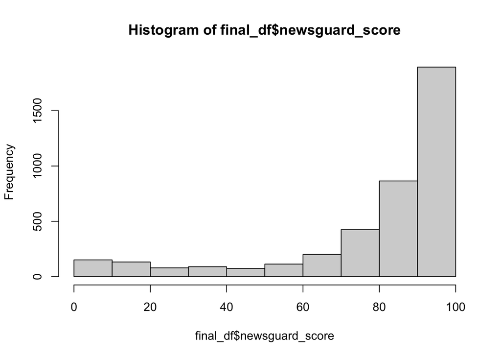

```r
# Check the distribution of our outcome (newsguard_score)
hist(final_df$newsguard_score)
```

```r
final_df |> mutate(
  newsguard_score_perc = newsguard_score/100
) -> final_df
```

Why use Beta Regression?

- Y (newsguard_score_perc) is a proportion bounded between 0 and 1 (or 0 and 100 for original scle).
- Linear regression (OLS) assumes normally distributed residuals, which is violated in this case (skewed distribution).
- Beta regression models data that follows a Beta distribution, allowing for flexible variance (heteroskedasticity).

## 2.1 Model 1. Shares

```r
model1 <- betareg(newsguard_score_perc ~
               age_deviation_score_shares +  average_yob_shares +
                 # gender_leaning_score_shares +
                 average_gender_score_shares + variance_gender_score_shares +
                 # political_leaning_score_shares +
                 average_party_score_shares + variance_party_score_shares +
                 race_deviation_score_shares +
                 shares + users,
               data = final_df)
vif(model1)
```

```
##   age_deviation_score_shares           average_yob_shares
##                    0.6664758                   -0.1433808
##  average_gender_score_shares variance_gender_score_shares
##                    1.1292099                    1.3267294
##   average_party_score_shares  variance_party_score_shares
##                    0.6806386                    1.3892623
##  race_deviation_score_shares                       shares
##                    1.1397561                    1.1442298
##                        users
##                    1.0826498
```

- VIFs are looking fine here (VIF < 5)
- If we include `gender_leaning_score_shares` or `political_leaning_score_shares` in the model, VIF gets too high so I removed them.

```r
summary(model1)
```

```
##
## Call:
## betareg(formula = newsguard_score_perc ~ age_deviation_score_shares +
##     average_yob_shares + average_gender_score_shares + variance_gender_score_shares +
##     average_party_score_shares + variance_party_score_shares + race_deviation_score_shares +
##     shares + users, data = final_df)
##
## Randomized quantile residuals:
##     Min      1Q  Median      3Q     Max
## -4.2265 -2.1817 -1.6565 -0.3150  5.0063
##
## Coefficients (mu model with logit link):
##                                Estimate Std. Error  z value Pr(>|z|)
## (Intercept)                  -1.755e+02  2.836e-01 -618.832  < 2e-16 ***
## age_deviation_score_shares   -2.390e+00  1.117e-01  -21.392  < 2e-16 ***
## average_yob_shares            9.054e-02  4.321e-05 2095.144  < 2e-16 ***
## average_gender_score_shares   2.102e+00  2.325e-01    9.039  < 2e-16 ***
## variance_gender_score_shares  6.507e+00  8.724e-01    7.459 8.69e-14 ***
## average_party_score_shares   -4.602e+00  1.929e-01  -23.855  < 2e-16 ***
## variance_party_score_shares   3.578e+00  1.499e+00    2.387    0.017 *
## race_deviation_score_shares  -1.028e-01  2.005e-01   -0.513    0.608
## shares                        1.096e-07  8.164e-06    0.013    0.989
## users                         5.138e-06  1.112e-05    0.462    0.644
##
## Phi coefficients (phi model with identity link):
##       Estimate Std. Error z value Pr(>|z|)
## (phi)   4.5764     0.1073   42.66   <2e-16 ***
##
## Exceedence parameter (extended-support xbetax model):
##         Estimate Std. Error z value Pr(>|z|)
## Log(nu) -1.28587    0.04756  -27.04   <2e-16 ***
## ---
## Signif. codes:  0 '***' 0.001 '**' 0.01 '*' 0.05 '.' 0.1 ' ' 1
##
## Exceedence parameter nu: 0.2764
## Type of estimator: ML (maximum likelihood)
## Log-likelihood: -5631 on 12 Df
## Number of iterations in BFGS optimization: 1
```

✔ Higher age diversity (age_deviation_score_shares) is associated with lower NewsGuard scores

✔ More male-dominated sharing (average_gender_score_shares) is associated with higher NewsGuard scores

✔ Greater gender diversity (variance_gender_score_shares) is associated with higher NewsGuard scores

✔ Politically skewed audiences (average_party_score_shares) are associated with lower NewsGuard scores

✔ More political diversity (variance_party_score_shares) is associated with higher NewsGuard scores

✔ Racial diversity (race_deviation_score_shares), the total number of shares (shares) and unique users (users) do not significantly impact NewsGuard scores (p > 0.05).

Just to check, I ran OLS as well:

```r
# Just to check: lm()
model1_lm <- lm(newsguard_score_perc ~
               age_deviation_score_shares +  average_yob_shares +
                 # gender_leaning_score_shares +
                 average_gender_score_shares + variance_gender_score_shares +
                 # political_leaning_score_shares +
                 average_party_score_shares + variance_party_score_shares +
                 race_deviation_score_shares +
                 shares + users,
               data = final_df)
vif(model1_lm)
```

```
##   age_deviation_score_shares           average_yob_shares
##                     2.158451                     1.731195
##  average_gender_score_shares variance_gender_score_shares
##                     1.091407                     1.355816
##   average_party_score_shares  variance_party_score_shares
##                     1.508645                     1.359835
##  race_deviation_score_shares                       shares
##                     1.115171                     3.124619
##                        users
##                     3.217145
```

```r
summary(model1_lm)
```

```
##
## Call:
## lm(formula = newsguard_score_perc ~ age_deviation_score_shares +
##     average_yob_shares + average_gender_score_shares + variance_gender_score_shares +
##     average_party_score_shares + variance_party_score_shares +
##     race_deviation_score_shares + shares + users, data = final_df)
##
## Residuals:
##      Min       1Q   Median       3Q      Max
## -0.95327 -0.08057  0.04030  0.11897  1.19685
##
## Coefficients:
##                                Estimate Std. Error t value Pr(>|t|)
## (Intercept)                  -2.117e+01  1.275e+00 -16.610  < 2e-16 ***
## age_deviation_score_shares   -2.125e-01  1.563e-02 -13.592  < 2e-16 ***
## average_yob_shares            1.118e-02  6.423e-04  17.403  < 2e-16 ***
## average_gender_score_shares   2.364e-01  2.063e-02  11.461  < 2e-16 ***
## variance_gender_score_shares -2.904e-03  8.984e-02  -0.032    0.974
## average_party_score_shares   -3.985e-01  2.223e-02 -17.923  < 2e-16 ***
## variance_party_score_shares   4.898e-01  1.130e-01   4.336 1.49e-05 ***
## race_deviation_score_shares   1.466e-02  1.475e-02   0.994    0.320
## shares                        1.396e-08  1.720e-08   0.811    0.417
## users                         7.225e-08  2.118e-07   0.341    0.733
## ---
## Signif. codes:  0 '***' 0.001 '**' 0.01 '*' 0.05 '.' 0.1 ' ' 1
##
## Residual standard error: 0.1971 on 4013 degrees of freedom
## Multiple R-squared:  0.3959, Adjusted R-squared:  0.3945
## F-statistic: 292.2 on 9 and 4013 DF,  p-value: < 2.2e-16
```

- Same result except for the gender diversity (variance_gender_score_shares): OLS X vs. Beta reg O
- OLS shrinks extreme effects because it assumes a constant variance. If gender diversity (variance_gender_score_shares) has a non-linear effect or interacts with other variables, OLS may not capture its full impact. vs. Beta Regression accounts for heteroskedasticity and handles non-linear relationships better.

[figure not shown]

## 2.2 Model 2. Users

```r
model2 <- betareg(newsguard_score_perc ~
               age_deviation_score_users +  average_yob_users +
                 average_gender_score_users + variance_gender_score_users +
                 average_party_score_users + variance_party_score_users +
                 race_deviation_score_users +
                 shares + users,
               data = final_df)
vif(model2)
```

```
##   age_deviation_score_users           average_yob_users
##                   1.4432276                  -0.9046236
##  average_gender_score_users variance_gender_score_users
##                   1.5235995                   0.8788422
##   average_party_score_users  variance_party_score_users
##                   0.9174253                   1.1935640
##  race_deviation_score_users                      shares
##                   1.2459435                   1.1459011
##                       users
##                   1.0545576
```

- VIFs looking good

```r
summary(model2)
```

```
##
## Call:
## betareg(formula = newsguard_score_perc ~ age_deviation_score_users +
##     average_yob_users + average_gender_score_users + variance_gender_score_users +
##     average_party_score_users + variance_party_score_users + race_deviation_score_users +
##     shares + users, data = final_df)
##
## Randomized quantile residuals:
##     Min      1Q  Median      3Q     Max
## -4.2946 -2.2297 -1.6704 -0.1789  4.3902
##
## Coefficients (mu model with logit link):
##                               Estimate Std. Error  z value Pr(>|z|)
## (Intercept)                  1.077e+02  4.760e-01  226.245  < 2e-16 ***
## age_deviation_score_users   -3.397e+00  1.320e-01  -25.744  < 2e-16 ***
## average_yob_users           -5.553e-02  5.622e-05 -987.768  < 2e-16 ***
## average_gender_score_users   2.753e+00  2.991e-01    9.203  < 2e-16 ***
## variance_gender_score_users  2.661e+01  9.422e-01   28.240  < 2e-16 ***
## average_party_score_users   -8.224e+00  2.771e-01  -29.675  < 2e-16 ***
## variance_party_score_users   1.814e+01  2.374e+00    7.640 2.17e-14 ***
## race_deviation_score_users  -3.259e+00  3.865e-01   -8.433  < 2e-16 ***
## shares                       9.433e-09  8.364e-06    0.001    0.999
## users                        2.217e-06  1.128e-05    0.197    0.844
##
## Phi coefficients (phi model with identity link):
##       Estimate Std. Error z value Pr(>|z|)
## (phi)   5.1143     0.1231   41.54   <2e-16 ***
##
## Exceedence parameter (extended-support xbetax model):
##         Estimate Std. Error z value Pr(>|z|)
## Log(nu)  -1.2859     0.0487   -26.4   <2e-16 ***
## ---
## Signif. codes:  0 '***' 0.001 '**' 0.01 '*' 0.05 '.' 0.1 ' ' 1
##
## Exceedence parameter nu: 0.2764
## Type of estimator: ML (maximum likelihood)
## Log-likelihood: -5732 on 12 Df
## Number of iterations in BFGS optimization: 1
```

✔ Higher age diversity (age_deviation_score_shares) is associated with lower NewsGuard scores

✔ Younger users (higher average_yob_users) are associated with lower NewsGuard scores, opposite to the shares-based model!

✔ More male-dominated sharing (average_gender_score_shares) is associated with higher NewsGuard scores

✔ Greater gender diversity (variance_gender_score_shares) is associated with higher NewsGuard scores

✔ Politically skewed audiences (average_party_score_shares) are associated with lower NewsGuard scores

✔ More political diversity (variance_party_score_shares) is associated with higher NewsGuard scores

✔ More racially diverse user bases (race_deviation_score_users) correlate with lower NewsGuard scores. (This was not significant in shares-based models!)

Just to check, OLS:

```r
# Just to check: lm()
model2_lm <- lm(newsguard_score_perc ~
                  age_deviation_score_users +
                    average_yob_users +
                    average_gender_score_users + variance_gender_score_users +
                    average_party_score_users + variance_party_score_users +
                    race_deviation_score_users +
                    shares + users,
               data = final_df)
vif(model2_lm)
```

```
##   age_deviation_score_users           average_yob_users
##                    6.118724                    5.606263
##  average_gender_score_users variance_gender_score_users
##                    1.240989                    1.166220
##   average_party_score_users  variance_party_score_users
##                    1.941844                    1.559644
##  race_deviation_score_users                      shares
##                    1.081159                    3.184314
##                       users
##                    3.466397
```

- High VIF between `age_deviation_score_users` and `average_yob_users`
- Let’s run the OLS regression in two versions: without `age_deviation_score_users`, and without `average_yob_users`

```r
lm(newsguard_score_perc ~
     # age_deviation_score_users +
       average_yob_users +
       average_gender_score_users + variance_gender_score_users +
       average_party_score_users + variance_party_score_users +
       race_deviation_score_users +
       shares + users,
   data = final_df) |> summary()
```

```
##
## Call:
## lm(formula = newsguard_score_perc ~ average_yob_users + average_gender_score_users +
##     variance_gender_score_users + average_party_score_users +
##     variance_party_score_users + race_deviation_score_users +
##     shares + users, data = final_df)
##
## Residuals:
##      Min       1Q   Median       3Q      Max
## -1.12865 -0.07086  0.03692  0.11132  0.69719
##
## Coefficients:
##                               Estimate Std. Error t value Pr(>|t|)
## (Intercept)                 -3.158e+01  1.498e+00 -21.085  < 2e-16 ***
## average_yob_users            1.614e-02  7.585e-04  21.278  < 2e-16 ***
## average_gender_score_users   3.160e-01  3.090e-02  10.226  < 2e-16 ***
## variance_gender_score_users  1.849e+00  1.296e-01  14.267  < 2e-16 ***
## average_party_score_users   -9.123e-01  2.648e-02 -34.450  < 2e-16 ***
## variance_party_score_users   2.907e+00  1.413e-01  20.570  < 2e-16 ***
## race_deviation_score_users  -1.071e-01  3.556e-02  -3.010  0.00263 **
## shares                       1.813e-08  1.624e-08   1.116  0.26446
## users                       -5.552e-07  2.055e-07  -2.702  0.00691 **
## ---
## Signif. codes:  0 '***' 0.001 '**' 0.01 '*' 0.05 '.' 0.1 ' ' 1
##
## Residual standard error: 0.1845 on 4014 degrees of freedom
## Multiple R-squared:  0.4708, Adjusted R-squared:  0.4697
## F-statistic: 446.3 on 8 and 4014 DF,  p-value: < 2.2e-16
```

```r
lm(newsguard_score_perc ~
     age_deviation_score_users +
       # average_yob_users +
       average_gender_score_users + variance_gender_score_users +
       average_party_score_users + variance_party_score_users +
       race_deviation_score_users +
       shares + users,
   data = final_df) |> summary()
```

```
##
## Call:
## lm(formula = newsguard_score_perc ~ age_deviation_score_users +
##     average_gender_score_users + variance_gender_score_users +
##     average_party_score_users + variance_party_score_users +
##     race_deviation_score_users + shares + users, data = final_df)
##
## Residuals:
##      Min       1Q   Median       3Q      Max
## -0.93816 -0.06539  0.03577  0.10275  0.80962
##
## Coefficients:
##                               Estimate Std. Error t value Pr(>|t|)
## (Intercept)                  5.117e-01  3.693e-02  13.857  < 2e-16 ***
## age_deviation_score_users   -3.080e-01  1.158e-02 -26.604  < 2e-16 ***
## average_gender_score_users   3.059e-01  2.939e-02  10.410  < 2e-16 ***
## variance_gender_score_users  1.375e+00  1.222e-01  11.248  < 2e-16 ***
## average_party_score_users   -7.196e-01  2.853e-02 -25.222  < 2e-16 ***
## variance_party_score_users   1.956e+00  1.472e-01  13.284  < 2e-16 ***
## race_deviation_score_users  -9.524e-02  3.455e-02  -2.757  0.00587 **
## shares                       1.075e-08  1.571e-08   0.684  0.49387
## users                       -4.120e-07  1.963e-07  -2.098  0.03593 *
## ---
## Signif. codes:  0 '***' 0.001 '**' 0.01 '*' 0.05 '.' 0.1 ' ' 1
##
## Residual standard error: 0.1794 on 4014 degrees of freedom
## Multiple R-squared:  0.4994, Adjusted R-squared:  0.4984
## F-statistic: 500.5 on 8 and 4014 DF,  p-value: < 2.2e-16
```